# MNIST in Keras with R

The MNIST database (Modified National Institute of Standards and Technology database) is a large database of labelled handwritten digits.

The MNIST database is also widely used for training and testing in the field of machine learning, and is considered the ‘Hello World’ task of image processing.

## Keras

We will be using the `Keras` library to construct the model. Keras is much more user-friendly than TensorFlow, and we will be able to push away some of the difficult parts to `Keras` to solve so we make fewer errors. Keras also comes with better defaults, so our models should have fewer simple errors (e.g. forgetting to add biases) overall.

### Load the MNIST Dataset

```r
library(keras)

mnist <- dataset_mnist()
x_train <- mnist$train$x
y_train <- mnist$train$y
x_test <- mnist$test$x
y_test <- mnist$test$y
```

### Visualise the data

Lets have a go at seeing the first few images in the dataset.

```r
library(tidyverse)
library(rbokeh)

rotate <- function(x) t(apply(x, 2, rev))

reshape_image <- function(x) {
  x %>%
    matrix(nrow = 28) %>%
    rotate()
}

imgs <- lapply(seq(1,100), function(i) rotate(x_train[i, 1:28, 1:28]))
image_data <- tibble(i = seq(1, 100), input = imgs)

# group a 10x10 collection of images together
imgs <- image_data %>%
  group_by(i %% 10) %>%
  summarise(row = list(Reduce(cbind, input))) %>%
  do(as_tibble(Reduce(rbind, .$row))) %>%
  as.matrix()

fig_params = list(xgrid = FALSE, ygrid = FALSE, xaxes = FALSE, yaxes = FALSE, tools = NULL)
black_and_white <- colorRampPalette(c('white', 'black'))(255)

plot_image <- function(x) {
  # create the plot
  do.call(figure, fig_params) %>%
    ly_image(x, palette = black_and_white)
}

plot_image(imgs)
```

[interactive chart not shown]

```r
# reshape data
dim(x_train) <- c(nrow(x_train), 784)
dim(x_test) <- c(nrow(x_test), 784)

y_train <- to_categorical(y_train, 10)
y_test <- to_categorical(y_test, 10)
```

```r
bad_model <- keras_model_sequential(name = 'bad_model')
bad_model %>%
  layer_dense(units = 16, activation = 'relu', input_shape = c(784)) %>%
  layer_dense(units = 10, activation = 'softmax')
```

```r
summary(bad_model)
```

```
## ___________________________________________________________________________
## Layer (type)                     Output Shape                  Param #
## ===========================================================================
## dense_1 (Dense)                  (None, 16)                    12560
## ___________________________________________________________________________
## dense_2 (Dense)                  (None, 10)                    170
## ===========================================================================
## Total params: 12,730
## Trainable params: 12,730
## Non-trainable params: 0
## ___________________________________________________________________________
```

```r
bad_model %>% compile(
  loss = 'categorical_crossentropy',
  optimizer = optimizer_rmsprop(),
  metrics = c('accuracy')
)
```

```r
history <- bad_model %>%
  fit(x_train, y_train,
  epochs = 30, batch_size = 128,
  validation_split = 0.2,
  callbacks = callback_tensorboard(
    log_dir = "logs", write_grads = TRUE, write_images = TRUE)
)
```

### Plot Loss and Accuracy

It’s easy to plot the loss and model accuracy.

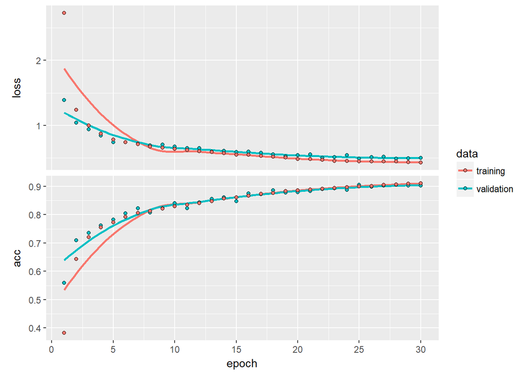

```r
plot(history)
```

It’s also easy to evaluate the model on the test data.

```r
bad_model %>% evaluate(x_test, y_test, verbose = 0)
```

```
## $loss
## [1] 0.5094569
##
## $acc
## [1] 0.8993
```

```r
entropy <- function(p) - sum(ifelse(p > 0, p * log(p), 0))

preds <- bad_model %>%
  predict_proba(x_test) %>%
  as_tibble()

colnames(preds) <- 0:9

preds <- tibble(
      class   = apply(preds,  1, which.max) - 1,
      target  = apply(y_test, 1, which.max) - 1,
      entropy = apply(preds,  1, entropy),
      image   = lapply(1:nrow(x_test), function(i) reshape_image(x_test[1, 1:28**2]))) %>%
  mutate(correct = class == target)

preds
```

```
## # A tibble: 10,000 x 5
##    class target      entropy           image correct
##    <dbl>  <dbl>        <dbl>          <list>   <lgl>
##  1     7      7 1.911195e-05 <int [28 x 28]>    TRUE
##  2     2      2 8.131698e-25 <int [28 x 28]>    TRUE
##  3     1      1 2.604063e-12 <int [28 x 28]>    TRUE
##  4     0      0 2.022480e-08 <int [28 x 28]>    TRUE
##  5     4      4 2.905867e-01 <int [28 x 28]>    TRUE
##  6     1      1 8.539714e-12 <int [28 x 28]>    TRUE
##  7     4      4 1.548239e-01 <int [28 x 28]>    TRUE
##  8     9      9 3.384879e-01 <int [28 x 28]>    TRUE
##  9     6      5 7.487489e-03 <int [28 x 28]>   FALSE
## 10     9      9 3.687970e-02 <int [28 x 28]>    TRUE
## # ... with 9,990 more rows
```

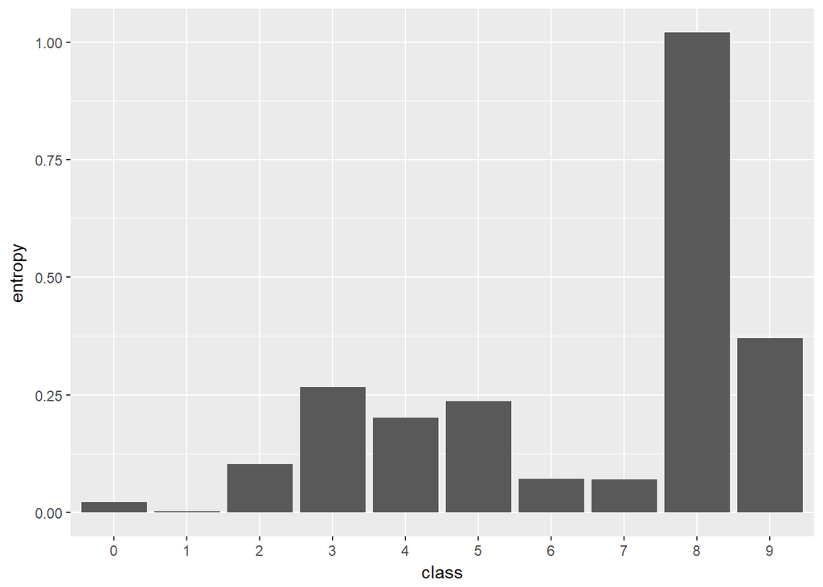

```r
preds %>%
  group_by(class) %>%
  summarise(entropy = mean(entropy)) %>%
  mutate(class = as.character(class)) %>%
  ggplot(aes(x = class, y = entropy)) +
  geom_bar(stat = 'identity')
```

Come here for the CNN model: https://keras.rstudio.com/articles/examples/mnist_cnn.html